# Разработка A/B-тестирования и анализ результатов

## Цель и задачи проекта

**Цель:**  
Провести A/B-тестирование нового алгоритма рекомендаций в развлекательном приложении с «бесконечной» лентой, чтобы определить, приводит ли внедрение этого алгоритма к увеличению вовлечённости пользователей и улучшению ключевых продуктовых метрик.

**Задачи:**

- Рассчитать параметры и необходимую длительность A/B-теста для проверки гипотезы о влиянии нового алгоритма.
- Оценить корректность проведения эксперимента: проверить равномерность распределения пользователей по группам, отсутствие пересечений, сопоставимость групп по ключевым признакам.
- Проанализировать результаты теста: сравнить ключевые метрики между контрольной и тестовой группами, определить статистическую значимость изменений.
- Сформулировать выводы и рекомендации по внедрению нового алгоритма рекомендаций на основе результатов теста.

## Описание данных

Для анализа используем три таблицы:

У этих таблиц почти совпадает структура и содержание колонок, различаются лишь периоды наблюдения.

Поля таблиц `sessions_project_history`, `sessions_project_test`, `sessions_project_test_part`:

- `user_id` — идентификатор пользователя;
- `session_id` — идентификатор сессии в приложении;
- `session_date` — дата сессии;
- `session_start_ts` — дата и время начала сессии;
- `install_date` — дата установки приложения;
- `session_number` — порядковый номер сессии для конкретного пользователя;
- `registration_flag` — является ли пользователь зарегистрированным;
- `page_counter` — количество просмотренных страниц во время сессии;
- `region` — регион пользователя;
- `device` — тип устройства пользователя;
- `test_group` — тестовая группа (в таблице с историческими данными этого столбца нет).

### 1. Работа с историческими данными (EDA)

#### 1.1. Загрузка исторических данных

```python
# Импортируем библиотеку pandas
import pandas as pd

# Импортируем библиотеку matplotlib для визуализации линейного графика
import matplotlib.pyplot as plt
# Импортируем библиотеку seaborn для визуализации распределения и построения KDE
import seaborn as sns

# Импортируем ttest_ind из scipy.stats для проведения стат.теста с помощью т-теста
from scipy.stats import ttest_ind
```

```python
# Сохраняем датасет sessions_project_history.csv в датафрейм sessions_history
# Датасет скрыт, т.к. является интеллектуальной собственностью Я.Практикум
sessions_history = pd.read_csv('secret_key')

# Выводим первые 5 строк
sessions_history.head()
```

|  | user_id | session_id | session_date | session_start_ts | install_date | session_number | registration_flag | page_counter | region | device |
| --- | --- | --- | --- | --- | --- | --- | --- | --- | --- | --- |
| 0 | E302123B7000BFE4 | F9AF61A0C2023832 | 2025-08-15 | 2025-08-15 17:47:35 | 2025-08-15 | 1 | 0 | 3 | CIS | iPhone |
| 1 | 2530F72E221829FB | 85003A206CBDAC6F | 2025-08-15 | 2025-08-15 16:42:14 | 2025-08-15 | 1 | 0 | 4 | MENA | Android |
| 2 | 876E020A4FC512F5 | 3677423E49D72DEE | 2025-08-15 | 2025-08-15 12:30:00 | 2025-08-15 | 1 | 0 | 4 | EU | PC |
| 3 | 2640B349E1D81584 | 956B45F5915CA225 | 2025-08-15 | 2025-08-15 15:31:31 | 2025-08-15 | 1 | 0 | 4 | CIS | Android |
| 4 | 94E1CBFAEF1F5EE9 | 83BF0DA35F9F1F40 | 2025-08-15 | 2025-08-15 21:33:53 | 2025-08-15 | 1 | 0 | 3 | CIS | Android |

```python
# Выводим структуру датафрейма с историческими данными
sessions_history.info()
```

```
<class 'pandas.core.frame.DataFrame'>
RangeIndex: 435924 entries, 0 to 435923
Data columns (total 10 columns):
 #   Column             Non-Null Count   Dtype
---  ------             --------------   -----
 0   user_id            435924 non-null  object
 1   session_id         435924 non-null  object
 2   session_date       435924 non-null  object
 3   session_start_ts   435924 non-null  object
 4   install_date       435924 non-null  object
 5   session_number     435924 non-null  int64
 6   registration_flag  435924 non-null  int64
 7   page_counter       435924 non-null  int64
 8   region             435924 non-null  object
 9   device             435924 non-null  object
dtypes: int64(3), object(7)
memory usage: 33.3+ MB
```

#### 1.2. Знакомство с данными

```python
# Группируем по user_id и считаем уникальные session_id
user_session_group = sessions_history.groupby('user_id')['session_id'].nunique().reset_index()

# Находим пользователя с максимальным числом сессий и выбираем первого
max_sessions = user_session_group['session_id'].max()
max_user = user_session_group[user_session_group['session_id'] == max_sessions].iloc[0]

print(f"Пользователь {max_user['user_id']} с наибольшим кол-ом сессий: {max_user['session_id']}")

# Выводим все строки по этому пользователю для изучения структуры данных
sessions_history[sessions_history['user_id'] == max_user['user_id']].reset_index(drop=True)
```

```
Пользователь 10E0DEFC1ABDBBE0 с наибольшим кол-ом сессий: 10
```

|  | user_id | session_id | session_date | session_start_ts | install_date | session_number | registration_flag | page_counter | region | device |
| --- | --- | --- | --- | --- | --- | --- | --- | --- | --- | --- |
| 0 | 10E0DEFC1ABDBBE0 | B8F0423BBFFCF5DC | 2025-08-14 | 2025-08-14 13:57:39 | 2025-08-14 | 1 | 0 | 4 | CIS | Android |
| 1 | 10E0DEFC1ABDBBE0 | 87CA2FA549473837 | 2025-08-15 | 2025-08-15 16:42:10 | 2025-08-14 | 2 | 0 | 3 | CIS | Android |
| 2 | 10E0DEFC1ABDBBE0 | 4ADD8011DCDCE318 | 2025-08-16 | 2025-08-16 19:53:21 | 2025-08-14 | 3 | 0 | 3 | CIS | Android |
| 3 | 10E0DEFC1ABDBBE0 | DF0FD0E09BF1F3D7 | 2025-08-17 | 2025-08-17 15:03:43 | 2025-08-14 | 4 | 0 | 1 | CIS | Android |
| 4 | 10E0DEFC1ABDBBE0 | 3C221774B4DE6885 | 2025-08-18 | 2025-08-18 17:29:14 | 2025-08-14 | 5 | 0 | 4 | CIS | Android |
| 5 | 10E0DEFC1ABDBBE0 | 031BD7A67048105B | 2025-08-19 | 2025-08-19 13:23:55 | 2025-08-14 | 6 | 0 | 2 | CIS | Android |
| 6 | 10E0DEFC1ABDBBE0 | FF4315CF4AD4B100 | 2025-08-20 | 2025-08-20 19:31:54 | 2025-08-14 | 7 | 0 | 2 | CIS | Android |
| 7 | 10E0DEFC1ABDBBE0 | 4045FEA0747203B4 | 2025-08-22 | 2025-08-22 17:54:13 | 2025-08-14 | 8 | 0 | 2 | CIS | Android |
| 8 | 10E0DEFC1ABDBBE0 | 344B086C421C7F37 | 2025-08-24 | 2025-08-24 14:46:13 | 2025-08-14 | 9 | 0 | 2 | CIS | Android |
| 9 | 10E0DEFC1ABDBBE0 | 054F20BA371E4C9D | 2025-08-25 | 2025-08-25 18:36:41 | 2025-08-14 | 10 | 0 | 3 | CIS | Android |

#### 1.3. Анализ числа регистраций

```python
# Группируем таблицу по уникальным пользователям и зарегистрированным
user_table = sessions_history.groupby('session_date').agg(unique_user=('user_id', 'nunique'),
                                                          reg_user=('registration_flag', 'sum'))

# Добавляем столбец с долей зарегистрированных пользователей от всех
user_table['share_reg_user'] = round(user_table.reg_user / user_table.unique_user, 3)

unique_user = user_table.unique_user
reg_user = user_table.reg_user
share_reg_user = user_table.share_reg_user
```

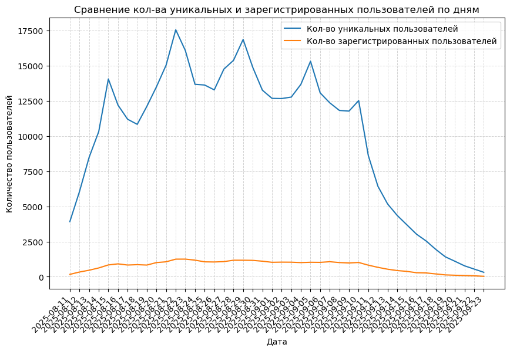

```python
# Создаем линейный график для сравнения кол-ва уникальных и зарегистрированных пользователей по дням
plt.figure(figsize=(10, 6))
plt.plot(unique_user, label='Кол-во уникальных пользователей')
plt.plot(reg_user, label='Кол-во зарегистрированных пользователей')

plt.xlabel("Дата")
plt.ylabel("Количество пользователей")
plt.xticks(rotation=45, ha='right')
plt.legend(loc='upper right')
plt.title('Сравнение кол-ва уникальных и зарегистрированных пользователей по дням')
plt.grid(color='lightgray',
         linestyle='--',
         linewidth=0.7)
plt.show()
```

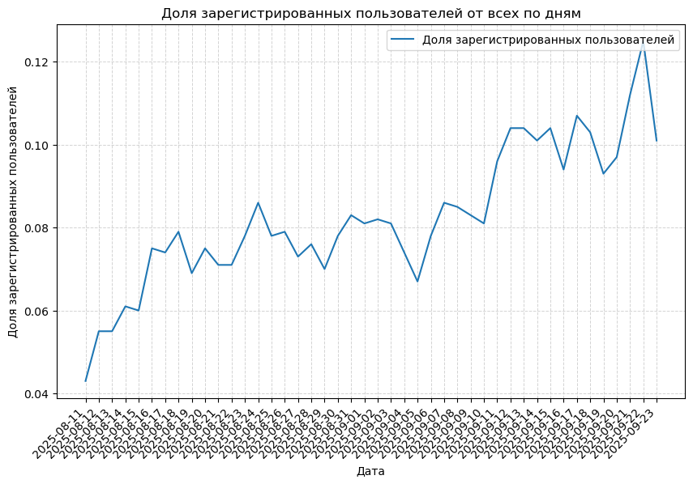

```python
# Создаем линейный график для отображения доли зарегистрированных от всех по дням
plt.figure(figsize=(10, 6))
plt.plot(share_reg_user, label='Доля зарегистрированных пользователей')

plt.xlabel("Дата")
plt.ylabel("Доля зарегистрированных пользователей")
plt.xticks(rotation=45, ha='right')
plt.legend(loc='upper right')
plt.title('Доля зарегистрированных пользователей от всех по дням')
plt.grid(color='lightgray',
         linestyle='--',
         linewidth=0.7)
plt.show()
```

**Вывод:**

- Графике видна недельная зависимость - к выходным кол-во уникальных пользователей растет;
  - Рост пользователей в выходные может быть связан с проведением досуга в дни отдыха;
- Доля зарегистрированных пользователей достаточно низкая. Пользователи предпочитают просматривать страницы без авторизации.
  - Возможных причин множество: ограничения или неудобства при регистрации, достаточный функционал в неавторизированной зоне и т.д.
- Также заметно, что после 10 сентября кол-во уникальных пользователей резко снижается;
  - На фоне снижения уникальных пользователей выросла доля зарегистрированных - отток преимущественно незарегистрированных пользователей.

#### 1.4. Анализ числа просмотренных страниц

```python
# Группируем данные по кол-во просмотренных страниц
page_counter_group = sessions_history.groupby('page_counter')['session_id'].count()
page_counter_group.to_frame('session_id')
```

| page_counter | session_id |
| --- | --- |
| 1 | 29160 |
| 2 | 105536 |
| 3 | 166690 |
| 4 | 105569 |
| 5 | 26288 |
| 6 | 2589 |
| 7 | 92 |

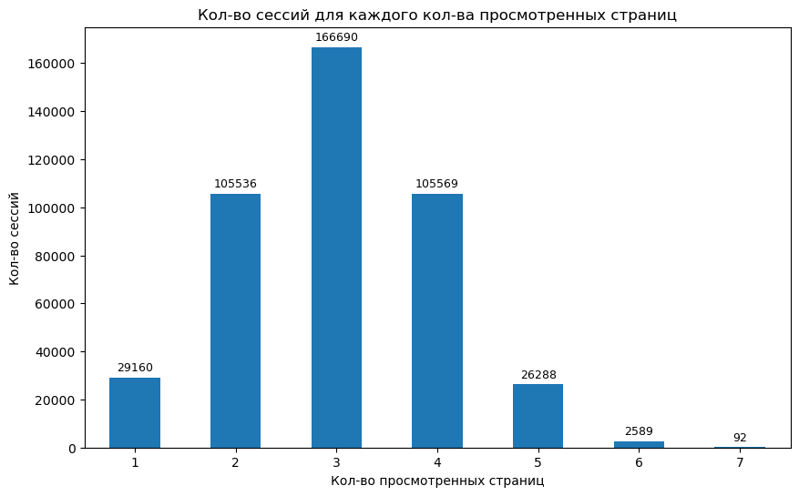

```python
# Создаем столбчатую диаграмму для отображения кол-ва сессий для каждого кол-ва просмотренных страниц
plt.figure(figsize=(10, 6))
page_counter_group.plot.bar()

plt.xlabel("Кол-во просмотренных страниц")
plt.ylabel("Кол-во сессий")
plt.xticks(rotation=0)
plt.title('Кол-во сессий для каждого кол-ва просмотренных страниц')

for idx, value in enumerate(page_counter_group):
    plt.text(idx, value + max(page_counter_group)*0.01, str(value), ha='center', va='bottom', fontsize=9)

plt.show()
```

**Вывод:**

- Больше всего сессий было в рамках 3 просмотренных страниц
- Также часто пользователи просматривают 2 и 4 страницы
- Менее всего смотря 6 и более страниц

#### 1.5. Доля пользователей, просмотревших более четырёх страниц

Продуктовая команда продукта считает, что сессии, в рамках которых пользователь просмотрел 4 и более страниц, говорят об удовлетворённости контентом и алгоритмами рекомендаций. Этот показатель является важной прокси-метрикой для продукта.

```python
# Создаем функцию для определения успешной сессии, если было просмотрено 4 и более страниц
def success_session(row):
    if row['page_counter'] >= 4:
        return 1
    else:
        return 0
```

```python
# Создаем столбец good_session c признаком успешной сессии с помощью функции success_session
sessions_history['good_session'] = sessions_history.apply(success_session, axis=1)
```

```python
# Группируем данные по дате и вычисляем долю успешных сессий
good_session_group = sessions_history.groupby('session_date').agg(all_session=('session_id', 'count'),
                                                        good_session=('good_session', 'sum'))
good_session_group['share_good_session'] = good_session_group['good_session'] / good_session_group['all_session']
```

```python
# Считаем среднее значение за весь период
mean_all = good_session_group['share_good_session'].mean()

# Считаем среднее значение за последние 2 недели (с момента спада метрики)
mean_last_period = good_session_group.tail(14)['share_good_session'].mean()

print(f'Среднее за весь период: {mean_all}')
print(f'Среднее за последний период: {mean_last_period}')
```

```
Среднее за весь период: 0.3075441043954679
Среднее за последний период: 0.30407531865138065
```

```python
# Вычисляем стандартное отклонение
std_dev = good_session_group['share_good_session'].std()
print(f"Стандартное отклонение: {std_dev}")
```

```
Стандартное отклонение: 0.006896745005637771
```

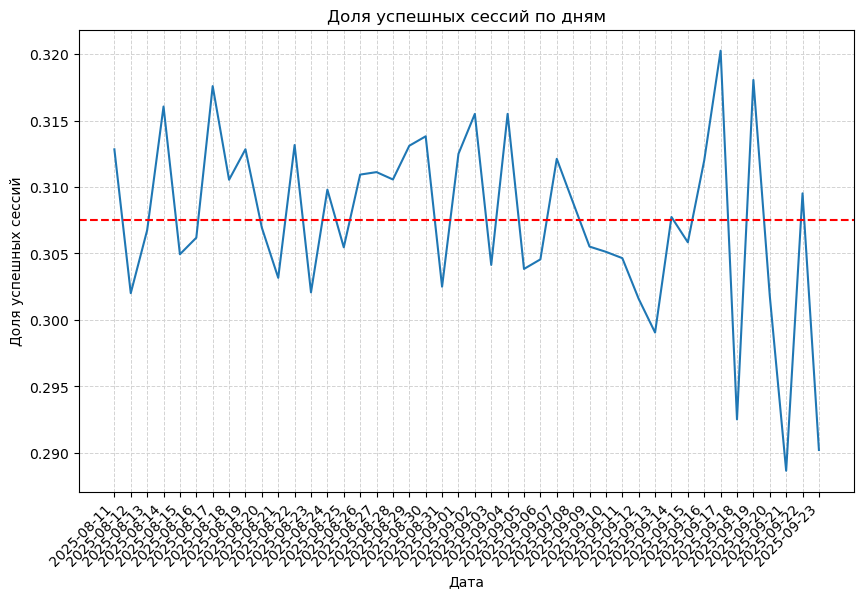

```python
# Создаем линейный график
plt.figure(figsize=(10, 6))
plt.plot(good_session_group['share_good_session'])

plt.xlabel("Дата")
plt.ylabel("Доля успешных сессий")
plt.xticks(rotation=45, ha='right')
plt.title('Доля успешных сессий по дням')
plt.grid(color='lightgray',
         linestyle='--',
         linewidth=0.7)

# Линия среднего значения
plt.axhline(mean_all, color='red', linestyle='--', label="Среднее значение")

plt.show()
```

**Вывод:**

- Доля пользователей с успешными сессиями варьируется от 0.30 до 0.32 до 10 сентября, при этом относительно стабильна;
- После 10 сентября менее стабильна и приобретает бОльший разброс от 0.28 до 0.32.

### 2. Подготовка к тесту

#### 2.1. Расчёт размера выборки

Параметры тесте:

- Уровень значимости — 0.05.
- Вероятность ошибки второго рода — 0.2.
- Мощность теста.
- Минимальный детектируемый эффект, или MDE, — 3%. Обратите внимание, что здесь нужно указать десятичную дробь, а не процент.

**Используем упрощенный вариант расчета выборки**

```python
from statsmodels.stats.power import NormalIndPower

# Задаём параметры
alpha = 0.05  # Уровень значимости
beta = 0.2  # Ошибка второго рода, часто 1 - мощность
power = 1 - beta  # Мощность теста
mde = 0.03  # Минимальный детектируемый эффект

# Инициализируем класс NormalIndPower
power_analysis = NormalIndPower()

# Рассчитываем размер выборки
sample_size = power_analysis.solve_power(
    effect_size = mde,
    power = power,
    alpha = alpha,
    ratio = 1 # Равномерное распределение выборок
)

print(f"Необходимый размер выборки для каждой группы: {int(sample_size)}")
```

```
Необходимый размер выборки для каждой группы: 17441
```

**Вывод:**

- Для каждой выборки нам необходимо набрать не менее 17441.

При этом важно отметить, что при расчете размера выборки через калькулятор, она должна составлять более 39 тыс.

#### 2.2. Расчёт длительности A/B-теста

```python
from math import ceil

# Среднее количество пользователей приложения в день по историческим данным
avg_daily_users = round(sessions_history.groupby('session_date')['user_id'].nunique().mean())

# Рассчитываем длительность теста в днях как отношение размера выборки к среднему числу пользователей
test_duration = ceil((sample_size * 2) / avg_daily_users)

print(f"Рассчитанная длительность A/B-теста при текущем уровне трафика в {avg_daily_users} пользователей в день составит {test_duration} дней")
```

```
Рассчитанная длительность A/B-теста при текущем уровне трафика в 9907 пользователей в день составит 4 дней
```

**Вывод:**

- При текущем уровне трафика в 9907 пользователей в день составит 4 дня

Так как кол-во пользователей у нас имеет недельную зависимость, то рекомендации округлить длительность до целой недели

### 3. Мониторинг А/В-теста

#### 3.1. Проверка распределения пользователей

```python
# Сохраняем датасет sessions_project_test_part.csv в датафрейм sessions_test_part
# Датасет скрыт, т.к. является интеллектуальной собственностью Я.Практикум
sessions_test_part = pd.read_csv('secret_key')
```

```python
# Группируем данные по группам теста и считаем кол-во уникальных пользователей
unique_user_test_group = sessions_test_part.groupby('test_group')['user_id'].nunique().to_frame('user_id')

a = unique_user_test_group.loc['A', 'user_id']
b = unique_user_test_group.loc['B', 'user_id']
```

```python
# Вычисляем процентную разницу в количестве пользователей между пользователями
perc_diff = round(100 * (abs(a- b) / a), 2)
print(f' Процентная разница пользователей в группах A и B составляет {perc_diff}%')
```

```
 Процентная разница пользователей в группах A и B составляет 0.74%
```

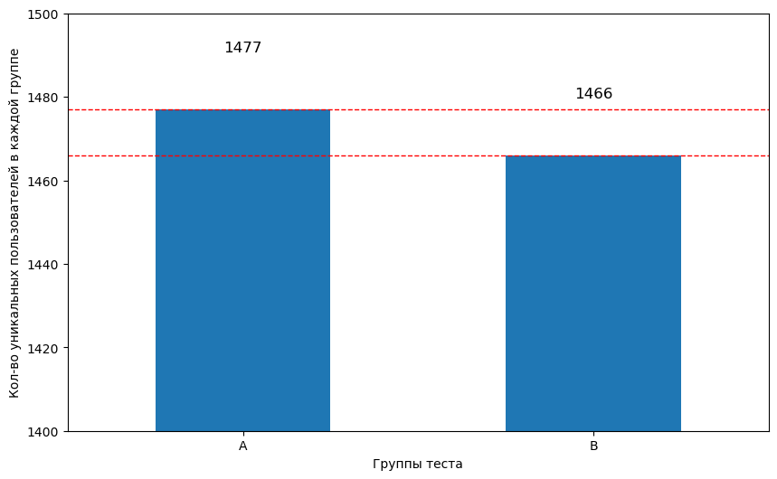

```python
# Создаем столбчатую диаграмму для отображения кол-ва сессий для каждого кол-ва просмотренных страниц
unique_user_bar = sessions_test_part.groupby('test_group')['user_id'].nunique()

plt.figure(figsize=(10, 6))
unique_user_bar.plot.bar()

plt.xlabel("Группы теста")
plt.ylabel("Кол-во уникальных пользователей в каждой группе")
plt.xticks(rotation=0)
plt.ylim(1400, 1500)
plt.title('')

for idx, value in enumerate(unique_user_bar):
    plt.text(idx, value + max(unique_user_bar)*0.01, str(value), ha='center', va='center', fontsize=12)
    plt.axhline(value, color='red', linestyle='--', linewidth=1)

plt.show()
```

#### 3.2. Проверка пересечений пользователей

```python
# Фильтруем список пользователей по группам и находим пересечения между группами
a_users = sessions_test_part[sessions_test_part['test_group'] == 'A']['user_id']
b_users = sessions_test_part[sessions_test_part['test_group'] == 'B']['user_id']

intersection_users = list(set(a_users) & set(b_users))

if not intersection_users:
    print('Пересечений пользователей в группах нет')
else:
    print(f'Список пересекающихся пользователей: \n{intersection_users}')
```

```
Пересечений пользователей в группах нет
```

**Вывод:**

- Пересечений пользователей в группах нет, поэтому рекомендации - проверить равномерность распределения и продолжить тест.

#### 3.3. Равномерность разделения пользователей по устройствам

```python
# Группируем данные по типу устройства и тестовой группе и вычисляем кол-во уникальных пользователей и их доли
group_device = sessions_test_part.groupby(['device', 'test_group'])['user_id'].nunique().to_frame('user_cnt')
group_device['share_user'] = round(group_device['user_cnt']
                                   / group_device.groupby('test_group')['user_cnt'].transform('sum'), 3)
group_device =  group_device.unstack(fill_value=0)
display(group_device)
```

| test_group device | user_cnt A | user_cnt B | share_user A | share_user B |
| --- | --- | --- | --- | --- |
| Android | 656 | 668 | 0.444 | 0.456 |
| Mac | 156 | 148 | 0.106 | 0.101 |
| PC | 369 | 381 | 0.250 | 0.260 |
| iPhone | 296 | 269 | 0.200 | 0.183 |

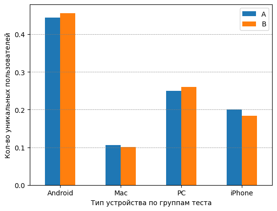

```python
# Создаем столбчатую диаграмму для сравнения распределения кол-ва
# уникальных пользователей по типу устройства между тестовыми группами
plt.figure(figsize=(10, 6))
group_device['share_user'].plot.bar()

plt.xlabel("Тип устройства по группам теста")
plt.ylabel("Кол-во уникальных пользователей")
plt.xticks(rotation=0)
plt.legend(loc='upper right')
plt.title('')
plt.grid(color='grey',
         linestyle='--',
         linewidth=0.5,
         axis='y')

plt.show()
```

**Вывод:**

- Распределение пользователей почти равномерное с небольшими перевесами в группах, что не критично в рамках проведения теста

#### 3.4. Равномерность распределения пользователей по регионам

```python
# Группируем данные по региону и тестовой группе и вычисляем кол-во уникальных пользователей и их доли
group_region = sessions_test_part.groupby(['region', 'test_group'])['user_id'].nunique().to_frame('user_cnt')
group_region['share_user'] = round(group_region['user_cnt']
                                   / group_region.groupby('test_group')['user_cnt'].transform('sum'), 3)
group_region =  group_region.unstack(fill_value=0)
display(group_region)
```

| test_group region | user_cnt A | user_cnt B | share_user A | share_user B |
| --- | --- | --- | --- | --- |
| CIS | 644 | 645 | 0.436 | 0.440 |
| EU | 224 | 217 | 0.152 | 0.148 |
| MENA | 609 | 604 | 0.412 | 0.412 |

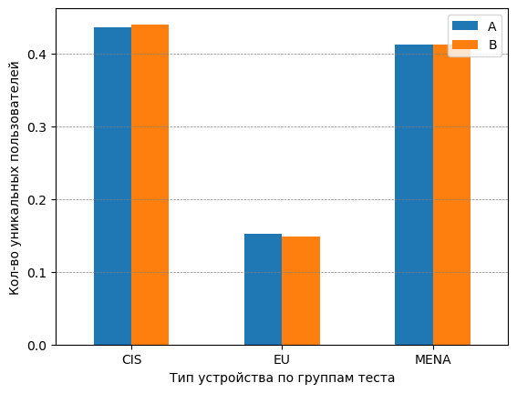

```python
# Создаем столбчатую диаграмму для сравнения распределения кол-ва
# уникальных пользователей по типу устройства между тестовыми группами
plt.figure(figsize=(10, 6))
group_region['share_user'].plot.bar()

plt.xlabel("Тип устройства по группам теста")
plt.ylabel("Кол-во уникальных пользователей")
plt.xticks(rotation=0)
plt.legend(loc='upper right')
plt.title('')
plt.grid(color='grey',
         linestyle='--',
         linewidth=0.5,
         axis='y')

plt.show()
```

**Вывод:**

- Распределение пользователей по регионам равномерное, поэтому можно продолжать тест

#### 3.5. Вывод после проверки A/B-теста

**Вывод:**

В рамках мониторинга проведения A/B-теста было выявлено следующее:

- Выявлены различия в количестве пользователей между группами, при этом разница оказалась несущественная;
- Пересечений пользователей в группах не было выявлено;
- Распределение пользователей по типам устройства и регионам достаточно равномерное с незначительными различиями.

**Вывод**: A/B-тест протекает корректно, рекомендации - продолжить A/B-тест

### 4. Проверка результатов A/B-теста

#### 4.1. Получение результатов теста и подсчёт основной метрики

```python
# Сохраняем датасет sessions_project_test.csv в датафрейм sessions_test
# Датасет скрыт, т.к. является интеллектуальной собственностью Я.Практикума
sessions_test = pd.read_csv('secret_key')
```

```python
# Создаем уже созданную функцию success_session в задании 1.5
# для определения успешной сессии, если было просмотрено 4 и более страниц

sessions_test['good_session'] = sessions_test.apply(success_session, axis=1)
```

#### 4.2. Проверка корректности результатов теста

```python
# Группируем данные по дате и тестовой группе и считаем кол-во уникальных пользователей
unique_session = sessions_test.groupby(['session_date', 'test_group'])['session_id'].nunique().reset_index()
```

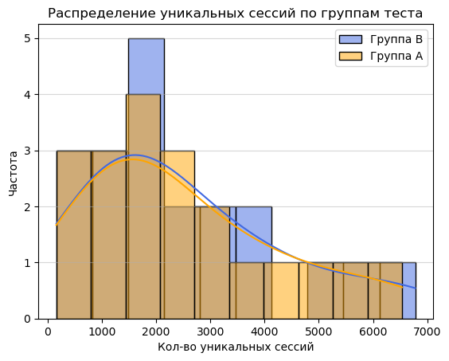

```python
# Визуализируем распределение кол-ва уникальных пользователей по группам
sns.histplot(unique_session[unique_session['test_group'] == 'B']['session_id'],
             bins=10,
             kde=True,
             label='Группа B',
             color='royalblue')
sns.histplot(unique_session[unique_session['test_group'] == 'A']['session_id'],
             bins=10,
             kde=True,
             label='Группа A',
             color='orange')
plt.title('Распределение уникальных сессий по группам теста')
plt.xlabel('Кол-во уникальных сессий')
plt.ylabel('Частота')
plt.legend(loc='upper right')
plt.grid(axis='y', linestyle='-', alpha=0.5)
plt.show()
```

```python
# Проверяем итоговое распределение клиентов по группам
sessions_test.groupby('test_group')['user_id'].nunique().to_frame('user_cnt')
```

| test_group | user_cnt |
| --- | --- |
| A | 15163 |
| B | 15416 |

У нас нет информации о дисперсии, а также кол-во значений в выборке немного (= 20) - т.е. распределение Стьюдента, стремящееся к нормальному распределению, то для проведения теста используем t-тест.

Сформулируем гипотезы для проведения стат теста:

- H0: Кол-во уникальных дневных сессий в двух выборках не отличается, т.е. среднии двух выборок равны (x̄A = x̄B)
- H1: Кол-во уникальных дневных сессий в двух выборках различаются, средние не равны (x̄A ≠ x̄B)

```python
# Проводим двусторонний статистический тест с помощью t-теста
test_result_pvalue = ttest_ind(
    unique_session[unique_session['test_group'] == 'A']['session_id'],
    unique_session[unique_session['test_group'] == 'B']['session_id'],
    alternative='two-sided'
).pvalue

if test_result_pvalue > alpha:
    print(f'pvalue={test_result_pvalue} > {alpha}')
    print('Не получилось отвергнуть нулевую гипотезу')
else:
    print(f'pvalue={test_result_pvalue} < {alpha}')
    print('Отвергаем нулевую гипотезу')
```

```
pvalue=0.938219304859116 > 0.05
Не получилось отвергнуть нулевую гипотезу
```

**Вывод:**

При проведении t-теста мы получили значение pvalue = 0.93, что больше уровня статистической значимости α, равному 0.05.

Это значит, что при текущем проведении статистического теста с данными параметрами у нас не получилось отвергнуть нулевую гипотезу, то есть не смогли отвергнуть гипотезу о том, что выборки равны

#### 4.3. Сравнение доли успешных сессий

```python
# Группируем по тестовым группам и считаем долю успешных сессий
good_session_group = sessions_test.groupby('test_group').agg({'good_session': 'sum',
                                                              'session_id': 'nunique'})
good_session_group['perc_good_session'] = round(100 * good_session_group['good_session']
                                                / good_session_group['session_id'], 3)
diff_perc_session = good_session_group.loc['B', 'perc_good_session'] - good_session_group.loc['A', 'perc_good_session']

display(good_session_group)
print(f'Разница доли успешных сессий между выборками: {diff_perc_session:.2f}%')
```

| test_group | good_session | session_id | perc_good_session |
| --- | --- | --- | --- |
| A | 15248 | 49551 | 30.772 |
| B | 16059 | 50454 | 31.829 |

```
Разница доли успешных сессий между выборками: 1.06%
```

**Вывод:**

- Нововведения повлияли на изучаемую метрику - долю успешных сессий. Показатель вырос почти 1.1%. Эта цифра может выглядеть не впечатляюще, т.к. метрика долевая, при этом за 1% может скрываться ощутимый эффект на другие бизнес-метрики (например, увеличение кол-ва рекламы, выручка и т.д.).
- Для подтверждения роста метрики необходимо провести статистический тест, который подтвердит, что изменение метрики связано с нововведениями, а не со случайным отклонением метрики.

#### 4.4. Насколько статистически значимо изменение ключевой метрики

#### Проведение статистического теста с помощью t-теста

```python
# Проводим двусторонний статистический тест с помощью t-теста
stat_test_pvalue = ttest_ind(
    sessions_test[sessions_test['test_group'] == 'A']['good_session'],
    sessions_test[sessions_test['test_group'] == 'B']['good_session'],
    alternative='two-sided'
).pvalue

if stat_test_pvalue > alpha:
    print(f'pvalue={stat_test_pvalue} > {alpha}')
    print('Не получилось отвергнуть нулевую гипотезу')
else:
    print(f'pvalue={stat_test_pvalue} < {alpha}')
    print('Отвергаем нулевую гипотезу')
```

```
pvalue=0.0003148608995858183 < 0.05
Отвергаем нулевую гипотезу
```

#### Проведение статистического теста с помощью z-теста

```python
# Считаем размер выборок в тестовых группах
n_a = sessions_test[sessions_test['test_group'] == 'A']['good_session'].shape[0]
n_b = sessions_test[sessions_test['test_group'] == 'B']['good_session'].shape[0]

# Считаем кол-во успешных сессий
m_a = sessions_test[sessions_test['test_group'] == 'A']['good_session'].sum()
m_b = sessions_test[sessions_test['test_group'] == 'B']['good_session'].sum()

# Считаем долю успешных операций
p_a = m_a / n_a
p_b = m_b / n_b

# Проверяем предпосылку о достаточности данных
if (p_a*n_a > 10)and((1-p_a)*n_a > 10)and(p_b*n_b > 10)and((1-p_b)*n_b > 10):
    print('Предпосылка о достаточном количестве данных выполняется')
else:
    print('Предпосылка о достаточном количестве данных НЕ выполняется')
```

```
Предпосылка о достаточном количестве данных выполняется
```

```python
# Импортируем proportions_ztest из statsmodels.stats.proportion
# для проведения стат.теста с помощью z-теста
from statsmodels.stats.proportion import proportions_ztest
```

```python
# Проводим двусторонний статистический тест с помощью z-теста
stat_ztest, p_value_ztest = proportions_ztest(
    [m_a, m_b],
    [n_a, n_b],
    alternative='two-sided'
)
if p_value_ztest > alpha:
    print(f'pvalue={p_value_ztest} > {alpha}')
    print('Нулевая гипотеза находит подтверждение!')
else:
    print(f'pvalue={p_value_ztest} < {alpha}')
    print('Нулевая гипотеза не находит подтверждения!')
```

```
pvalue=0.0003149479976072246 < 0.05
Нулевая гипотеза не находит подтверждения!
```

**Вывод:**

- При проведении t-теста мы получили значение pvalue = 0.0003, что меньше уровня статистической значимости α, равному 0.05.

Это значит, что при текущем проведении статистического теста у нас получилось отвергнуть нулевую гипотезу в пользу альтернативной, т.е. тест показал, что изменения возможны из-за нововведений

Дополнительно провели z-тест для проверки наших расчетов в t-тесте. Результаты подтвердились - мы отвергаем нулевую гипотезу в пользу альтернативной, т.е. в пользу внедрения нового алгоритма

#### 4.5. Вывод по результатам A/B-эксперимента

**Вывод:**